# Analyse

CRASTES de PAULET Damien

March 13, 2016

# 1èrs essais et comparaisons rapides

## 1ère génération

les données sont générées grace au script data_gen.sh, il prend enargument un nom de dossier dans lequel il va créer tout les fichiers nécessaires a l’analyse. (Attention l’execution est longue (5*750 exécutions de quicksort avec des tailles variables)).

```r
  raw = read.csv("~/Documents/M2R-ParallelQuicksort/data/full_gen_1/csvs/10_ThreadsRaw.csv");
  datas<-ddply(raw, c("Size", "Type"), summarize,
                num = length(Time), mean = mean(Time), sd = sd(Time),
                se = 2*sd/sqrt(num))
  raw_datas = ddply(raw, c("Size", "Type"))
datas;
```

```
##       Size        Type num       mean           sd           se
## 1      100    Built-in  50 0.00002324 3.696637e-05 1.045567e-05
## 2      100    Parallel  50 0.03613502 2.080048e-02 5.883264e-03
## 3      100  Sequential  50 0.00001150 9.560228e-06 2.704041e-06
## 4     1000    Built-in  50 0.00086632 2.965564e-03 8.387882e-04
## 5     1000    Parallel  50 0.13323656 6.307142e-02 1.783929e-02
## 6     1000  Sequential  50 0.00061704 1.260586e-03 3.565477e-04
## 7    10000    Built-in  50 0.00526380 4.983920e-03 1.409666e-03
## 8    10000    Parallel  50 0.35418076 1.591914e-01 4.502613e-02
## 9    10000  Sequential  50 0.00641444 4.935063e-03 1.395847e-03
## 10  100000    Built-in  50 0.07485762 1.539657e-02 4.354807e-03
## 11  100000    Parallel  50 0.57471592 1.507820e-01 4.264759e-02
## 12  100000  Sequential  50 0.07527018 1.630111e-02 4.610651e-03
## 13 1000000    Built-in  50 0.67026904 3.214274e-01 9.091340e-02
## 14 1000000    Parallel  50 0.97407898 4.900268e-01 1.386005e-01
## 15 1000000  Sequential  50 0.67799572 3.383504e-01 9.569995e-02
```

Simplifions l’analyse avec un peu d’affichage graphique

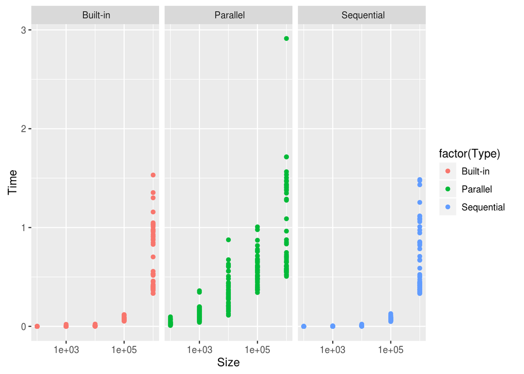

```r
ggplot(data = raw_datas, aes(x=Size, y=Time, color=factor(Type))) + geom_point() + scale_x_log10() + facet_wrap(~Type)
```

Maintenant on peut voir que le tri sequentiel et celui de base du C sont très similaires au niveau des performances, les valeurs en temps étant dans le même intervalle pour toutes les tailles.

On voit aussi que le tri multithreadé est certes plus lent sur ces tailles mais il semble suivre une courbe de regression linéaire et non exponentielle, il va falloir creuser ça.

## 2ème génération

cette fois si on pousse l’algorithme un peu plus loin avec des tableaux de 10 millions d’éléments, le script a pour cela était modifié pour générer plus de données et en prévision de l’étapde d’analyse du threading, le code à était augmenté afin de permettre la selection facile du nombre de threads.

```r
raw = read.csv("~/Documents/M2R-ParallelQuicksort/data/full_gen_2/csvs/10_ThreadsRaw.csv");
  raw_datas = ddply(raw, c("Size", "Type"))
  datas<-ddply(raw, c("Size", "Type"), summarize,
                num = length(Time), mean = mean(Time), sd = sd(Time),
                se = 2*sd/sqrt(num))
  datas;
```

```
##        Size        Type num       mean           sd           se
## 1       100    Built-in  50 0.00001450 8.830028e-06 2.497509e-06
## 2       100    Parallel  50 0.00916706 7.000444e-03 1.980024e-03
## 3       100  Sequential  50 0.00001248 1.805913e-05 5.107894e-06
## 4      1000    Built-in  50 0.00022918 6.173898e-05 1.746242e-05
## 5      1000    Parallel  50 0.02631688 1.088895e-02 3.079859e-03
## 6      1000  Sequential  50 0.00014360 6.228539e-05 1.761697e-05
## 7     10000    Built-in  50 0.00172460 2.042153e-04 5.776080e-05
## 8     10000    Parallel  50 0.04773514 1.835764e-02 5.192326e-03
## 9     10000  Sequential  50 0.00180302 2.685682e-04 7.596256e-05
## 10   100000    Built-in  50 0.02003370 1.151818e-03 3.257833e-04
## 11   100000    Parallel  50 0.09763420 2.449262e-02 6.927558e-03
## 12   100000  Sequential  50 0.02083394 1.087409e-03 3.075658e-04
## 13  1000000    Built-in  50 0.24645544 1.794670e-02 5.076095e-03
## 14  1000000    Parallel  50 0.35125830 3.181021e-02 8.997286e-03
## 15  1000000  Sequential  50 0.25592598 3.173166e-02 8.975068e-03
## 16 10000000    Built-in  50 3.37946660 9.150057e-01 2.588027e-01
## 17 10000000    Parallel  50 3.47792096 8.807598e-01 2.491165e-01
## 18 10000000  Sequential  50 3.32845958 8.628474e-01 2.440501e-01
```

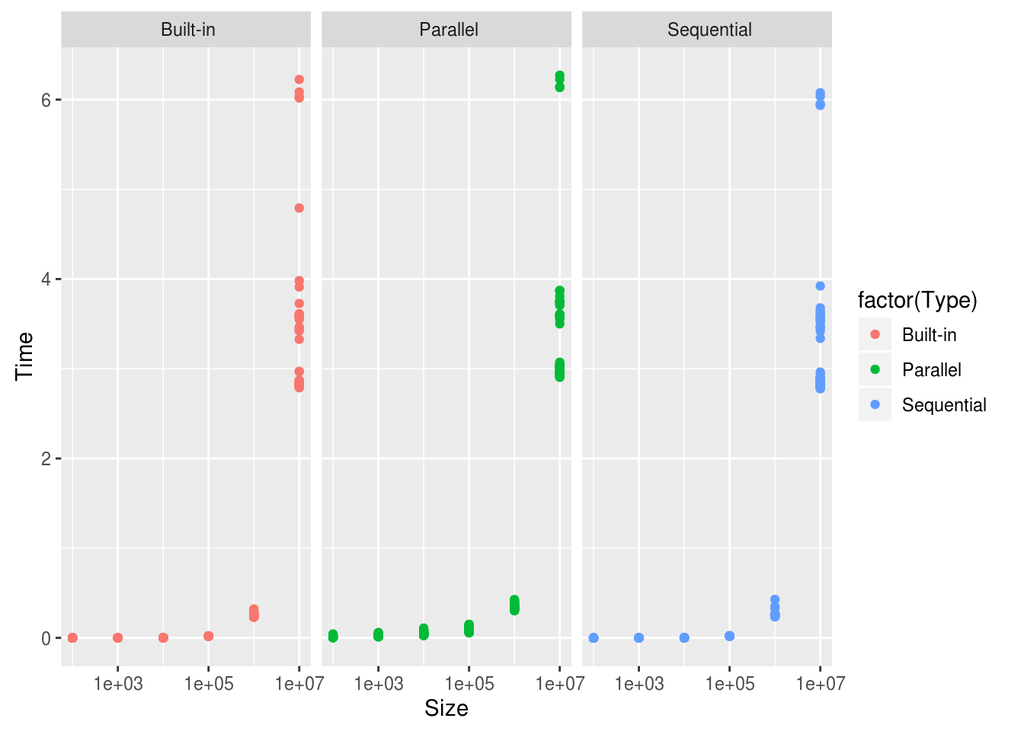

```r
  ggplot(data = raw_datas, aes(x=Size, y=Time, color=factor(Type))) + geom_point() + scale_x_log10() + facet_wrap(~Type)
```

Il semblerait que contrairement aux attentes, la durée de traitement par multi-threading suive en fait la même courbe que les autres traitements. Pourquoi met on alors autant de temps pour 1000000 d’éléments quand on le compare aux autres?

## Influence du nombre de thread

Vu que le nombre d’éléments semble ne pas être le critère principal de distinction, la réponse la plus logique à cette question serait que le temps de commnication entre les threads compense le gain possible de performances.

On génère donc de nouvelles données d’études, avec plusieurs niveau de threads. On a donc 1,2,5,10 (déja traité) et 20 threads en données analysables.

A chaque affichage graphique, les données du tri Built-In et Sequentiel seront présente pour la lisibilité.

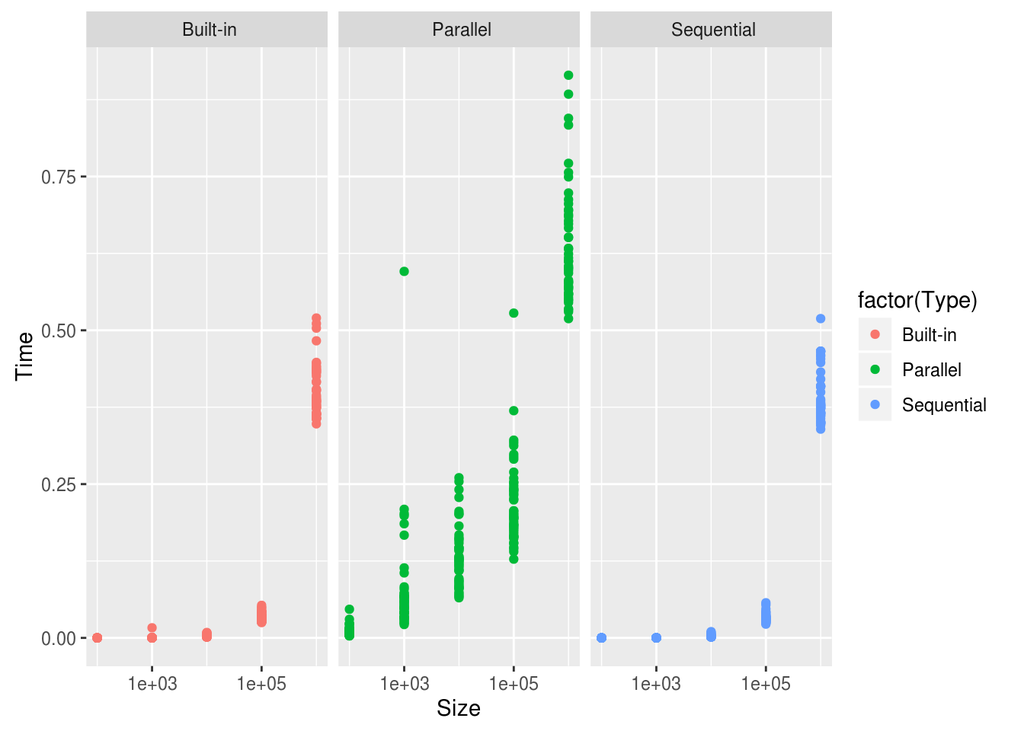

```r
FtoR=NULL
for(i in c(1,2,5,10,20)){
  FtoR[i] = paste("~/Documents/M2R-ParallelQuicksort/data/full_gen_1/csvs/",i,"_ThreadsRaw.csv",sep = "");
}

raw1T = read.csv(FtoR[1]);
raw2T = read.csv(FtoR[2]);
raw5T = read.csv(FtoR[5]);
raw20T = read.csv(FtoR[20]);
raw10T = read.csv(FtoR[10])

  raw_datas1T = ddply(raw1T, c("Size", "Type"))
  ggplot(data = raw_datas1T, aes(x=Size, y=Time, color=factor(Type))) + geom_point() + scale_x_log10() + facet_wrap(~Type)
```

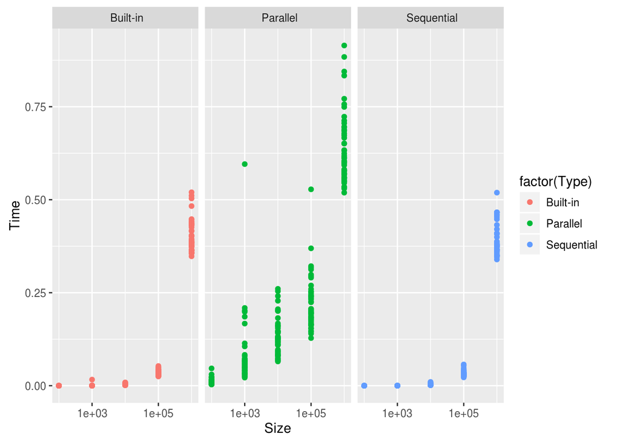

```r
  raw_datas2T = ddply(raw1T, c("Size", "Type"))
  ggplot(data = raw_datas2T, aes(x=Size, y=Time, color=factor(Type))) + geom_point() + scale_x_log10() + facet_wrap(~Type)
```

```r
  raw_datas5T = ddply(raw5T, c("Size", "Type"))
  datas5T<-ddply(raw5T, c("Size", "Type"), summarize,
                num = length(Time), mean = mean(Time), sd = sd(Time),
                se = 2*sd/sqrt(num))
  datas5T;
```

```
##       Size        Type num       mean           sd           se
## 1      100    Built-in  50 0.00001472 2.321505e-06 6.566209e-07
## 2      100    Parallel  50 0.00808426 5.381072e-03 1.521997e-03
## 3      100  Sequential  50 0.00001096 4.694591e-06 1.327831e-06
## 4     1000    Built-in  50 0.00037518 4.044001e-04 1.143816e-04
## 5     1000    Parallel  50 0.05424520 3.224122e-02 9.119194e-03
## 6     1000  Sequential  50 0.00032880 6.584107e-04 1.862267e-04
## 7    10000    Built-in  50 0.00325828 2.216193e-03 6.268341e-04
## 8    10000    Parallel  50 0.13535272 4.451897e-02 1.259186e-02
## 9    10000  Sequential  50 0.00339304 2.545913e-03 7.200929e-04
## 10  100000    Built-in  50 0.03687636 1.035936e-02 2.930069e-03
## 11  100000    Parallel  50 0.25676314 9.779398e-02 2.766031e-02
## 12  100000  Sequential  50 0.03790362 1.939085e-02 5.484560e-03
## 13 1000000    Built-in  50 0.47101636 1.676996e-01 4.743260e-02
## 14 1000000    Parallel  50 0.76230868 2.670142e-01 7.552303e-02
## 15 1000000  Sequential  50 0.45892700 1.633366e-01 4.619855e-02
```

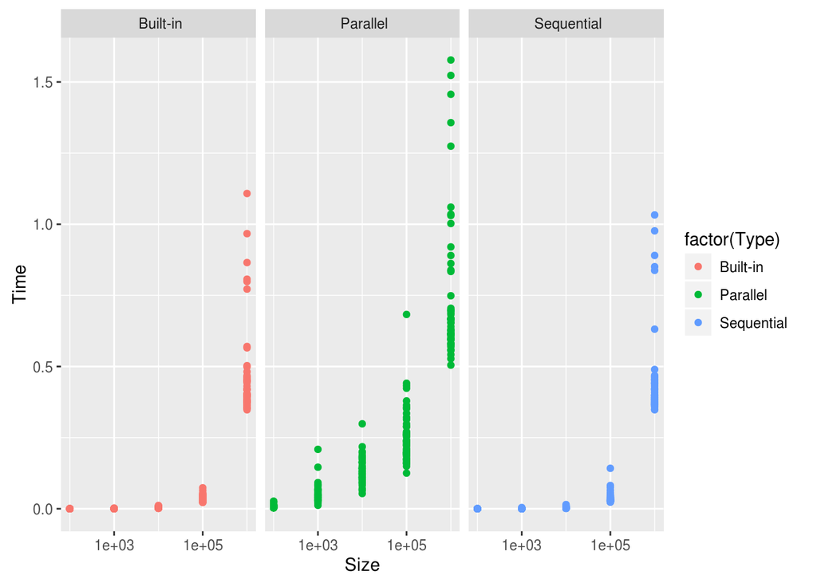

```r
  ggplot(data = raw_datas5T, aes(x=Size, y=Time, color=factor(Type))) + geom_point() + scale_x_log10() + facet_wrap(~Type)
```

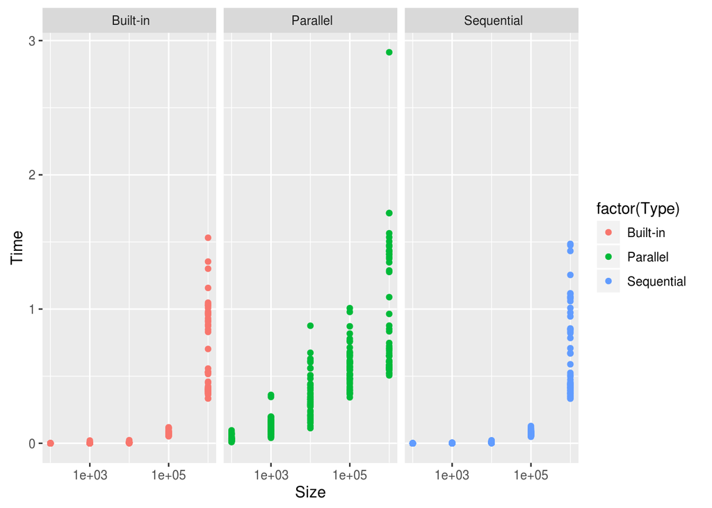

```r
  raw_datas10T = ddply(raw10T, c("Size", "Type"))
  ggplot(data = raw_datas10T, aes(x=Size, y=Time, color=factor(Type))) + geom_point() + scale_x_log10() + facet_wrap(~Type)
```

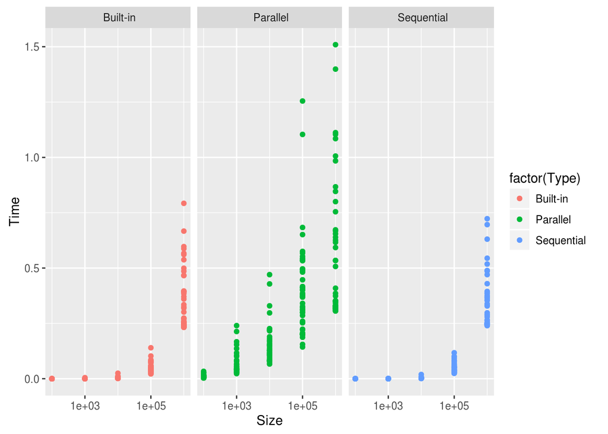

```r
  raw_datas20T = ddply(raw20T, c("Size", "Type"))
  ggplot(data = raw_datas20T, aes(x=Size, y=Time, color=factor(Type))) + geom_point() + scale_x_log10() + facet_wrap(~Type)
```

# Conclusion

Dans le cas de ma machine, il est assez facile de tirer des conclusions sur les performances du multi-Threading. Pour des tableaux de peite taille, la différence est importante comparé au temps d’éxécution, cea le rend donc inéficace.

Meme en réduisant le nombre de threads pour réduire la perte en communication, on observe les mêmes résutats.

Enfin, pour de grands tableaux, le temps moyen reste supérieur, mais la différence devient minime.

Pour la comparaison entre le modèle séquentiel et celui Built_In, il est difficile de distinguer une véritable différence de performance. Il peut donc être utile de le porter le modèle séquentiel en remplacement du Built-In pour pouvoir exécuter cet algorithme sur plus de machine.